# Estatística no R

# Análise fatorial exploratória

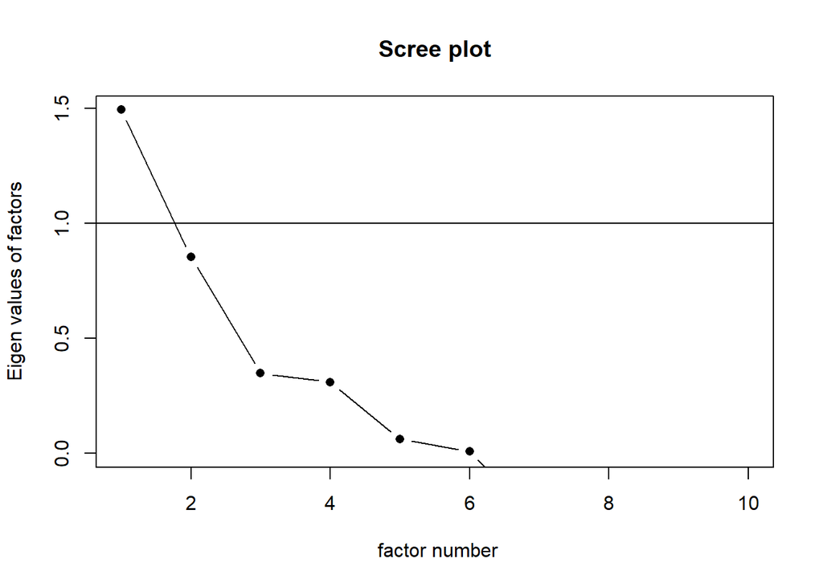

```r
# ANÁLISE FATORIAL DO TIPI

## Determinação do número de fatores a serem retidos
rwas %>% dplyr::select(48:57) %>% scree(pc = FALSE)
```

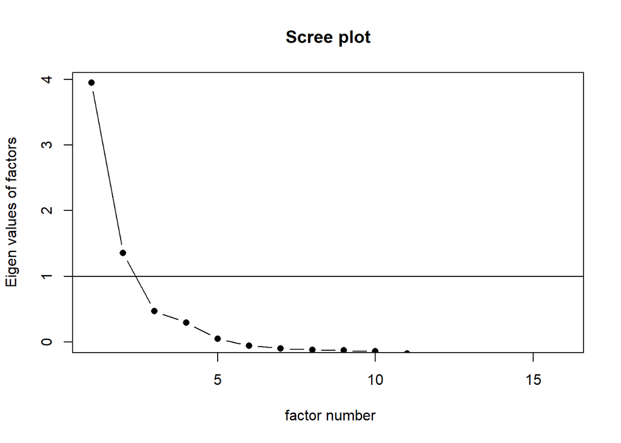

```r
## AFE
fa_tipi <- rwas %>% dplyr::select(48:57) %>% fa(nfactors = 5,
                                                cor = "cor",
                                                fm = "wls",
                                                rotate = "geominQ")

# ANÁLISE FATORIAL DO VCL

## Determinação do número de fatores a serem retidos
rwas %>% dplyr::select(58:73) %>% scree(pc = FALSE)
```

```r
## AFE
fa_rv <- rwas %>% dplyr::select(58:73) %>% fa(nfactors = 2,
                                              cor = "tet",
                                              fm = "wls")
```

```r
summary(fa_rv)
```

```
##
## Factor analysis with Call: fa(r = ., nfactors = 2, fm = "wls", cor = "tet")
##
## Test of the hypothesis that 2 factors are sufficient.
## The degrees of freedom for the model is 89  and the objective function was  2.91
## The number of observations was  9881  with Chi Square =  28717.76  with prob <  0
##
## The root mean square of the residuals (RMSA) is  0.07
## The df corrected root mean square of the residuals is  0.09
##
## Tucker Lewis Index of factoring reliability =  0.754
## RMSEA index =  0.18  and the 10 % confidence intervals are  0.179 0.182
## BIC =  27899.1
##  With factor correlations of
##      WLS1 WLS2
## WLS1 1.00 0.22
## WLS2 0.22 1.00
```

```r
fa_rv$Structure
```

```
##
## Loadings:
##       WLS1   WLS2
## VCL1   0.891
## VCL2   0.893  0.352
## VCL3   0.662  0.579
## VCL4   0.903
## VCL5   0.863  0.254
## VCL6   0.110  0.664
## VCL7   0.567  0.529
## VCL8   0.471  0.410
## VCL9          0.726
## VCL10  0.859  0.115
## VCL11  0.522  0.471
## VCL12  0.237  0.588
## VCL13  0.790  0.434
## VCL14  0.797  0.470
## VCL15  0.891
## VCL16  0.832
##
##                 WLS1  WLS2
## SS loadings    7.956 2.954
## Proportion Var 0.497 0.185
## Cumulative Var 0.497 0.682
```

```r
# OBS: O resultados com dois fatores é interessante porque o segundo fator é exatamente com os itens 6, 9 e 12, que não são palavras reais.

# Eliminação de itens que apresentaram cargas mais baixas.
fa_rv1 <- rwas %>% dplyr::select(58:62,64:65,67:68,70:73) %>% fa(nfactors = 1,
                                              cor = "tet",
                                              fm = "wls")
```

```r
summary(fa_rv1)
```

```
##
## Factor analysis with Call: fa(r = ., nfactors = 1, fm = "wls", cor = "tet")
##
## Test of the hypothesis that 1 factor is sufficient.
## The degrees of freedom for the model is 65  and the objective function was  3.64
## The number of observations was  9881  with Chi Square =  35929.13  with prob <  0
##
## The root mean square of the residuals (RMSA) is  0.12
## The df corrected root mean square of the residuals is  0.13
##
## Tucker Lewis Index of factoring reliability =  0.693
## RMSEA index =  0.236  and the 10 % confidence intervals are  0.234 0.238
## BIC =  35331.23
```

```r
fa_rv1$Structure
```

```
##
## Loadings:
##       WLS1
## VCL1  0.859
## VCL2  0.902
## VCL3  0.718
## VCL4  0.866
## VCL5  0.858
## VCL7  0.632
## VCL8  0.525
## VCL10 0.830
## VCL11 0.581
## VCL13 0.823
## VCL14 0.828
## VCL15 0.852
## VCL16 0.773
##
##                 WLS1
## SS loadings    7.942
## Proportion Var 0.611
```

# Análises de efeitos de pertencimento a grupos

Em muitas pesquisas, o interesse recai sobre os efeitos de grupo. Nesses casos, investiga-se se o fato das pessoas perteceram a um grupo produz algum efeito em alguma variável psicológica. Por exemplo, qual é o efeito de sexo (masculino ou feminino) na variável inteligência? Qual é o efeito de um programa de desenvolvimento da inteligência emocional (grupos controle e experimental) sobre a qualidade de vida? Qual o efeito do país de origem (A, B, C) no desempenho escolar? As análises estatísticas que normalmente são usadas nesses estudos são as seguintes:

Teste t Análise de variância de duas vias (ANOVA) Análise de varância univariada Análise de variância multivariada (MANOVA) - Anova Fatorial Análise de Covariância (ANCOVA) Análise Multivariada de Covariância (MANCOVA) Análise de variância por medidas repetidas

## Teste t

Quando queremos comparar uma variável do nosso banco de dados com os dados constantes na literatura (por exemplo, as pontuações em depressão da nossa amostra com a média da população), usamos o **teste t para uma amostra**. Como exemplo, vamos usar o banco de dados `big_five_BR`, para investigar se as pontuações em neuroticismo dos brasileiros é significativamente diferentes da média encontrada nos diversos países em que a escala foi aplicada. Para isso, começamos investigando se a distribuição das pontuações é ao menos próxima da distribuição normal.

### Análise do pressuposto de normalidade

O ideal é empregar o teste de Shapiro-Wilk para a verificação da normalidade da variável que se quer testar. No entanto, esse teste, geralmente, resulta em diferença significativa, mesmo quando a distribuição é muito próxima da normal. Por isso, costuma-se usar parâmetros um pouco mais flexíveis, que são os índices de assimetria e curtose.

```r
#shapiro.test(dataset$neur)

skew(big_five_BR$amab,na.rm = TRUE)
```

```
## [1] -0.3359957
```

```r
kurtosi(big_five_BR$amab,na.rm = TRUE)
```

```
## [1] -0.3126487
```

### Média da amostra completa (referência)

```r
média_neur <- big_five %>%
  filter(!país == "BR") %>%
  dplyr::select("neur")

round(mean(média_neur$neur, na.rm = TRUE),digits = 2)
```

```
## [1] 3.09
```

### Cálculo do teste-t

```r
t.test(big_five_BR$neur,mu = 3.1)
```

```
##
##  One Sample t-test
##
## data:  big_five_BR$neur
## t = 3.8376, df = 174, p-value = 0.0001736
## alternative hypothesis: true mean is not equal to 3.1
## 95 percent confidence interval:
##  3.214347 3.456510
## sample estimates:
## mean of x
##  3.335429
```

# Representação Gráfica

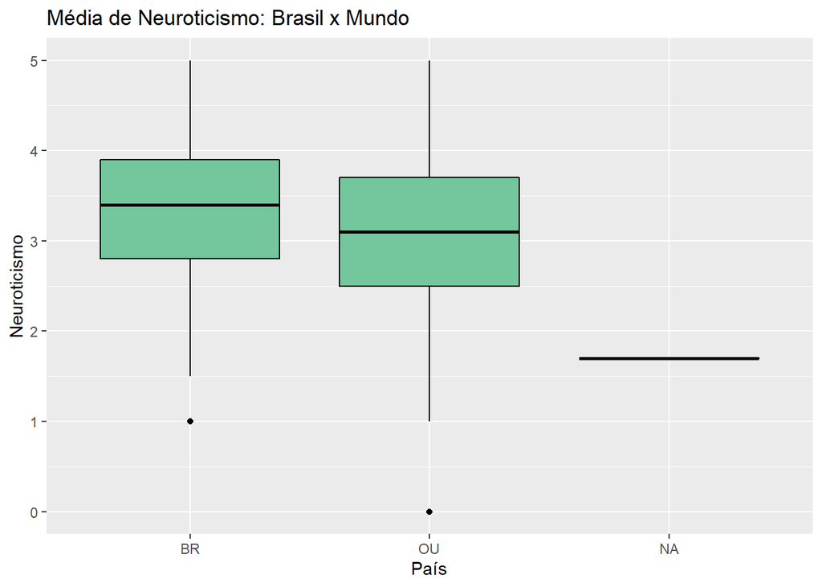

```r
big_five %>% mutate(Brasil = ifelse(país == "BR","BR","OU")) %>%
  ggplot(aes(x = Brasil, y = neur)) +
  geom_boxplot(color = "black", fill = "#74c69d") +
  labs(title = "Média de Neuroticismo: Brasil x Mundo",
       x = "País",
       y = "Neuroticismo")
```